# act_report

## Act Report

_This is a brief report about analysis performed and insights derived from the tweet_archive*master dataset, a cleaned and merged version of the three individual datasets provided for this project.*

- First, I wanted to determine the most popular breed of dog from the tweet data available. Using a bar chart as shown below, we could tell that the top five dog breeds by number of tweets were:
  1. Golden Retriever - 143
  2. Labrador Retriever - 100
  3. Pembroke - 90
  4. Chihuahua - 89
  5. Pug - 58

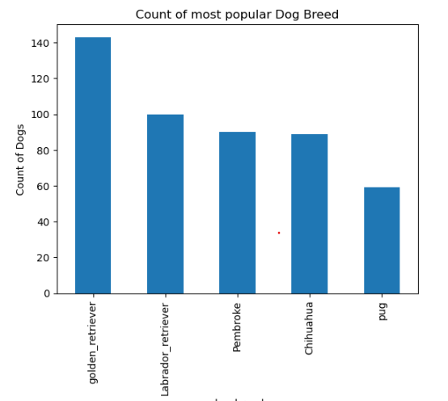

- I also explored the most popular dog stage using a bar chart. This were the order of popularity by the number of tweets per dog stage
  1. Pupper
  2. Doggo
  3. Puppo
  4. Floofer

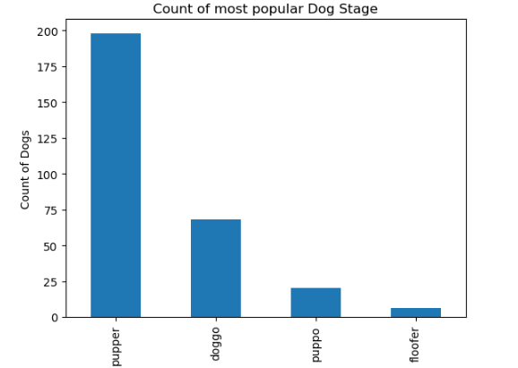

- Next, I tried to distribute the tweets by weekdays to see if there was a day or days in the week that had a higher tweet active. This was just to see if a pattern could be established about the user's social behavior as it relates to tweet activity in the days of the week. Monday has the highest tweet activity and staurday had the lowest but the range was relatively not large. The range between the peak activity day and lowest activity days were approximately 70 tweets.
- This means a random difference of about 10 tweets per day/level and should not be enough to conclude on a tweet pattern.
- Finally, I group the data by dog names and counted the most popular dog names based on the available data.
  1. The most populare were Charlie, Penny, Cooper, Tucker and Oliver, each appearing nine times.
  2. The close second were Winston, Luccy and Sadie. They all appeared eight times each.
  3. Third was Lola, and
  4. The fourth most popular name was Koda